# M606 Machine Learning

# Introduction

Customer turnover in the telecom industry is associated with a very critical issue that has been found to reflect the rate at which the customers have stopped using the services of a company within a certain period of time. With the help of analyzing the state, it can help companies to understand the behavior of customers as well as predict future trends. it can also be helpful to develop strategies which can be helpful to retain the customers. There are several key aspects and the data features which are involved in the telecom customer show analysis such as identification of customers can be helpful to understand the customers who have stopped using the services. By a building predictive model, it can also be helpful in identifying the risk of churning and segmenting customers.

## Problem Statement

The underlying business problem is associated with identifying and mitigating the factors which are leading towards the turn of the customer in the telecom industry. The customer's joint is also associated with reference to the phenomena where the customers have stopped using the service of the company and switched to the competitors (Ramesh et al., 2022). It is also a very critical issue due to acquiring a new customer who often finds it more costly than retaining the existing one which can significantly impact the revenue and profitability.

##### Importance of the problem

The revenue loss can be there as each customer has the potential to lower the recurring revenue. Increased cost can also be associated with acquiring a new customer which will cost more than retaining an existing one. The reduction of churn can increase the average customer lifetime value which can contribute to better long-term financial health.

##### The benefit of solving the problem

The reduction of churn can be helpful in maintaining a steady revenue stream from existing customers. The lower churn can also provide less need for expensive marketing campaigns which are aimed at acquiring new customers. Addressing the root cause of John can also improve overall customer satisfaction whereas the accurate insights from analysis can also be helpful to inform broader business strategies as well as improvement in the operational strategy (Maulud, and Abdulazeez, 2020).

##### Collection of data

the effective analysis and prediction of customer join can be done with the help of using the different data where the customer demographic account information pattern of usage and service information can be there. Willing information and customer support interaction can also be there in the data.

##### Formulating problems as a machine learning task

The primary objective is associated with predicting the customer if there is a chance to turn in the near future. The next would be the data preparation where feature engine ring handling of missing data and encoding of categorical variables can be done (Bharadiya, 2023). The train test split and selection of model can also be done followed by evaluating the model and feature importance.

# Data Analysis and Finding

## Data Exploration

### Libraries/Modules

```python
import pandas as pd
import numpy as np
import matplotlib.pyplot as plt
import warnings
import seaborn as sns
warnings.filterwarnings('ignore')
from sklearn.preprocessing import StandardScaler
from sklearn.preprocessing import LabelEncoder
```

The libraries are usable to configure the test bench platform that is applicable for execution. The process of execution involves all the necessary steps such as data read, data clean, and so on. Each library or module is applicable to implement the data execution process.

### Data read section

```python
data_file = pd.read_csv('WA_Fn-UseC_-Telco-Customer-Churn.csv')
data_file.head()
```

|  | customerID | gender | SeniorCitizen | Partner | Dependents | tenure | PhoneService | MultipleLines | InternetService | OnlineSecurity | ... | DeviceProtection | TechSupport | StreamingTV | StreamingMovies | Contract | PaperlessBilling | PaymentMethod | MonthlyCharges | TotalCharges | Churn |
| --- | --- | --- | --- | --- | --- | --- | --- | --- | --- | --- | --- | --- | --- | --- | --- | --- | --- | --- | --- | --- | --- |
| 0 | 7590-VHVEG | Female | 0 | Yes | No | 1 | No | No phone service | DSL | No | ... | No | No | No | No | Month-to-month | Yes | Electronic check | 29.85 | 29.85 | No |
| 1 | 5575-GNVDE | Male | 0 | No | No | 34 | Yes | No | DSL | Yes | ... | Yes | No | No | No | One year | No | Mailed check | 56.95 | 1889.5 | No |
| 2 | 3668-QPYBK | Male | 0 | No | No | 2 | Yes | No | DSL | Yes | ... | No | No | No | No | Month-to-month | Yes | Mailed check | 53.85 | 108.15 | Yes |
| 3 | 7795-CFOCW | Male | 0 | No | No | 45 | No | No phone service | DSL | Yes | ... | Yes | Yes | No | No | One year | No | Bank transfer (automatic) | 42.30 | 1840.75 | No |
| 4 | 9237-HQITU | Female | 0 | No | No | 2 | Yes | No | Fiber optic | No | ... | No | No | No | No | Month-to-month | Yes | Electronic check | 70.70 | 151.65 | Yes |

5 rows × 21 columns

The reading approach is applicable to read the collected data and configure the main structure of the data frame. The structure of the full data frame provides information about the overall data portion.

### Cleaning and evaluation

```python
data_file.info()
```

```
<class 'pandas.core.frame.DataFrame'>
RangeIndex: 7043 entries, 0 to 7042
Data columns (total 21 columns):
 #   Column            Non-Null Count  Dtype
---  ------            --------------  -----
 0   customerID        7043 non-null   object
 1   gender            7043 non-null   object
 2   SeniorCitizen     7043 non-null   int64
 3   Partner           7043 non-null   object
 4   Dependents        7043 non-null   object
 5   tenure            7043 non-null   int64
 6   PhoneService      7043 non-null   object
 7   MultipleLines     7043 non-null   object
 8   InternetService   7043 non-null   object
 9   OnlineSecurity    7043 non-null   object
 10  OnlineBackup      7043 non-null   object
 11  DeviceProtection  7043 non-null   object
 12  TechSupport       7043 non-null   object
 13  StreamingTV       7043 non-null   object
 14  StreamingMovies   7043 non-null   object
 15  Contract          7043 non-null   object
 16  PaperlessBilling  7043 non-null   object
 17  PaymentMethod     7043 non-null   object
 18  MonthlyCharges    7043 non-null   float64
 19  TotalCharges      7043 non-null   object
 20  Churn             7043 non-null   object
dtypes: float64(1), int64(2), object(18)
memory usage: 1.1+ MB
```

The information of the data frame defines the involvement of various data types such as object, float, and integer. This data type helps in further investigation process and finding the main executional value point (Jamil et al., 2021).

```python
data_file.isna().sum()
```

```
customerID          0
gender              0
SeniorCitizen       0
Partner             0
Dependents          0
tenure              0
PhoneService        0
MultipleLines       0
InternetService     0
OnlineSecurity      0
OnlineBackup        0
DeviceProtection    0
TechSupport         0
StreamingTV         0
StreamingMovies     0
Contract            0
PaperlessBilling    0
PaymentMethod       0
MonthlyCharges      0
TotalCharges        0
Churn               0
dtype: int64
```

```python
data_file = data_file.drop(['customerID'], axis = 1)
data_file.head()
```

|  | gender | SeniorCitizen | Partner | Dependents | tenure | PhoneService | MultipleLines | InternetService | OnlineSecurity | OnlineBackup | DeviceProtection | TechSupport | StreamingTV | StreamingMovies | Contract | PaperlessBilling | PaymentMethod | MonthlyCharges | TotalCharges | Churn |
| --- | --- | --- | --- | --- | --- | --- | --- | --- | --- | --- | --- | --- | --- | --- | --- | --- | --- | --- | --- | --- |
| 0 | Female | 0 | Yes | No | 1 | No | No phone service | DSL | No | Yes | No | No | No | No | Month-to-month | Yes | Electronic check | 29.85 | 29.85 | No |
| 1 | Male | 0 | No | No | 34 | Yes | No | DSL | Yes | No | Yes | No | No | No | One year | No | Mailed check | 56.95 | 1889.5 | No |
| 2 | Male | 0 | No | No | 2 | Yes | No | DSL | Yes | Yes | No | No | No | No | Month-to-month | Yes | Mailed check | 53.85 | 108.15 | Yes |
| 3 | Male | 0 | No | No | 45 | No | No phone service | DSL | Yes | No | Yes | Yes | No | No | One year | No | Bank transfer (automatic) | 42.30 | 1840.75 | No |
| 4 | Female | 0 | No | No | 2 | Yes | No | Fiber optic | No | No | No | No | No | No | Month-to-month | Yes | Electronic check | 70.70 | 151.65 | Yes |

The data preprocessing approach is one of the main functional portions that is implemented to process the data for the main execution. In this context, the process is divided into multiple steps and an executional portion. At this point, one of the main process approaches is defined which is the drop approach (Mahesh, 2020). This approach is applicable to drop only that column that has no functional value in this process. In this case, ‘customerID’ has no significant value for the execution, so, this column is removed by using the drop approach.

```python
data_file['TotalCharges'] = pd.to_numeric(data_file.TotalCharges, errors='coerce')
```

```python
data_file.info()
```

```
<class 'pandas.core.frame.DataFrame'>
RangeIndex: 7043 entries, 0 to 7042
Data columns (total 20 columns):
 #   Column            Non-Null Count  Dtype
---  ------            --------------  -----
 0   gender            7043 non-null   object
 1   SeniorCitizen     7043 non-null   int64
 2   Partner           7043 non-null   object
 3   Dependents        7043 non-null   object
 4   tenure            7043 non-null   int64
 5   PhoneService      7043 non-null   object
 6   MultipleLines     7043 non-null   object
 7   InternetService   7043 non-null   object
 8   OnlineSecurity    7043 non-null   object
 9   OnlineBackup      7043 non-null   object
 10  DeviceProtection  7043 non-null   object
 11  TechSupport       7043 non-null   object
 12  StreamingTV       7043 non-null   object
 13  StreamingMovies   7043 non-null   object
 14  Contract          7043 non-null   object
 15  PaperlessBilling  7043 non-null   object
 16  PaymentMethod     7043 non-null   object
 17  MonthlyCharges    7043 non-null   float64
 18  TotalCharges      7032 non-null   float64
 19  Churn             7043 non-null   object
dtypes: float64(2), int64(2), object(16)
memory usage: 1.1+ MB
```

The conversion approach is applicable to convert the object column into a float data column. In this case, the ‘TotalCharges’ column is the object column which is converted into the float data column.

```python
data_file['Churn'] = data_file['Churn'].map({'No': 0, 'Yes': 1})
```

```python
data_file.info()
```

```
<class 'pandas.core.frame.DataFrame'>
RangeIndex: 7043 entries, 0 to 7042
Data columns (total 20 columns):
 #   Column            Non-Null Count  Dtype
---  ------            --------------  -----
 0   gender            7043 non-null   object
 1   SeniorCitizen     7043 non-null   int64
 2   Partner           7043 non-null   object
 3   Dependents        7043 non-null   object
 4   tenure            7043 non-null   int64
 5   PhoneService      7043 non-null   object
 6   MultipleLines     7043 non-null   object
 7   InternetService   7043 non-null   object
 8   OnlineSecurity    7043 non-null   object
 9   OnlineBackup      7043 non-null   object
 10  DeviceProtection  7043 non-null   object
 11  TechSupport       7043 non-null   object
 12  StreamingTV       7043 non-null   object
 13  StreamingMovies   7043 non-null   object
 14  Contract          7043 non-null   object
 15  PaperlessBilling  7043 non-null   object
 16  PaymentMethod     7043 non-null   object
 17  MonthlyCharges    7043 non-null   float64
 18  TotalCharges      7032 non-null   float64
 19  Churn             7043 non-null   int64
dtypes: float64(2), int64(3), object(15)
memory usage: 1.1+ MB
```

The data preprocessing approach introduces the mapping process to convert the object section into a numeric data section. In this context, the churn column has ‘No’, and ‘Yes’ object data values. These data values are converted into 0, and 1 respected by using the map approach.

### Visualization

```python
gender_wise_churn = data_file[data_file['Churn'] == 1].groupby('gender')['Churn'].sum().reset_index()
gender_wise_churn.head()
```

|  | gender | Churn |
| --- | --- | --- |
| 0 | Female | 939 |
| 1 | Male | 930 |

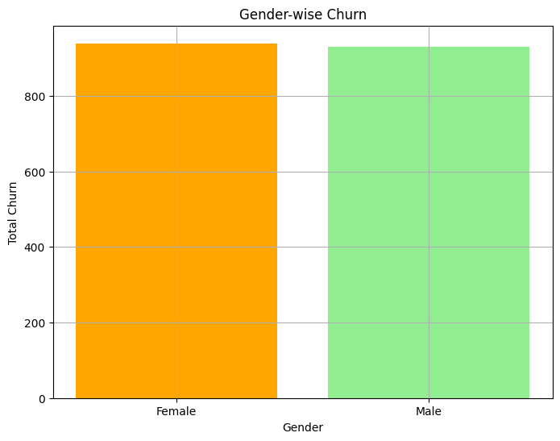

```python
plt.figure(figsize=(8, 6))
plt.bar(gender_wise_churn['gender'], gender_wise_churn['Churn'], color=['orange', 'lightgreen'])
plt.xlabel('Gender')
plt.ylabel('Total Churn')
plt.title('Gender-wise Churn')
plt.grid(True)
plt.show()
```

The first visualization portion highlights the churn evaluation with respect to the gender data. As per the plot, the female has 939 churn values whereas, the male has 930 churn values.

```python
phoneservice_wise_churn = data_file[data_file['Churn'] == 1].groupby('PhoneService')['Churn'].sum().reset_index()
phoneservice_wise_churn.head()
```

|  | PhoneService | Churn |
| --- | --- | --- |
| 0 | No | 170 |
| 1 | Yes | 1699 |

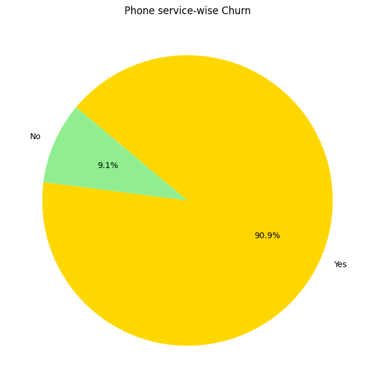

```python
plt.figure(figsize=(8, 8))
plt.pie(phoneservice_wise_churn['Churn'], labels=phoneservice_wise_churn['PhoneService'], autopct='%1.1f%%', colors=['lightgreen', 'gold'], startangle=140)
plt.title('Phone service-wise Churn')
plt.show()
```

In the case of phone service churn execution, the maximum churn is found in the case of yes-type phone service whose percentage is 90.9%. This assists in understanding the impact of the phone service on the churn execution.

```python
internetservice_wise_churn = data_file[data_file['Churn'] == 1].groupby('InternetService')['Churn'].sum().reset_index()
internetservice_wise_churn.head()
```

|  | InternetService | Churn |
| --- | --- | --- |
| 0 | DSL | 459 |
| 1 | Fiber optic | 1297 |
| 2 | No | 113 |

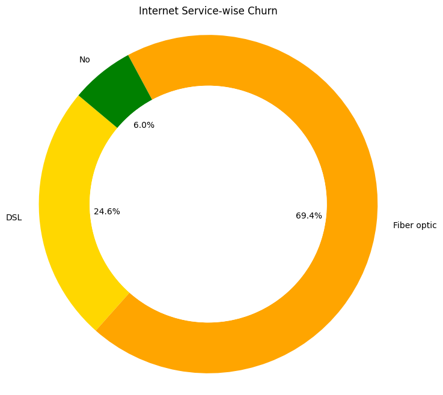

```python
plt.figure(figsize=(8, 8))
wedges, texts, autotexts = plt.pie(internetservice_wise_churn['Churn'], labels=internetservice_wise_churn['InternetService'], autopct='%1.1f%%', colors=['gold', 'orange', 'green'], startangle=140, wedgeprops=dict(width=0.3))
centre_circle = plt.Circle((0, 0), 0.70, fc='white')
fig = plt.gcf()
fig.gca().add_artist(centre_circle)
plt.title('Internet Service-wise Churn')
plt.axis('equal')
plt.show()
```

The plot executes the churn evaluation for internet service providing. As per the outcome plot, the maximum churn is found in the case of the fiber optics section which is 69.4%. On the other hand, minimum churn is found in no internet service case which is 6%.

```python
onlinesecurity_wise_churn = data_file[data_file['Churn'] == 1].groupby('OnlineSecurity')['Churn'].sum().reset_index()
onlinesecurity_wise_churn.head()
```

|  | OnlineSecurity | Churn |
| --- | --- | --- |
| 0 | No | 1461 |
| 1 | No internet service | 113 |
| 2 | Yes | 295 |

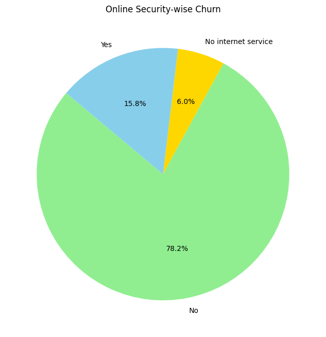

```python
plt.figure(figsize=(8, 8))
plt.pie(onlinesecurity_wise_churn['Churn'], labels=onlinesecurity_wise_churn['OnlineSecurity'], autopct='%1.1f%%', colors=['lightgreen', 'gold', 'skyblue'], startangle=140)
plt.title('Online Security-wise Churn')
plt.show()
```

The churn execution for online security evaluates the finding of maximum churn in the online security providing section. In this case, maximum churn is found in the No-type online service-providing section which is 78.2%.

```python
deviceprotection_wise_churn = data_file[data_file['Churn'] == 1].groupby('DeviceProtection')['Churn'].sum().reset_index()
deviceprotection_wise_churn.head()
```

|  | DeviceProtection | Churn |
| --- | --- | --- |
| 0 | No | 1211 |
| 1 | No internet service | 113 |
| 2 | Yes | 545 |

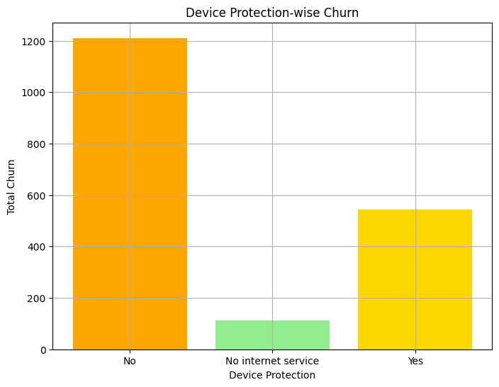

```python
plt.figure(figsize=(8, 6))
plt.bar(deviceprotection_wise_churn['DeviceProtection'], deviceprotection_wise_churn['Churn'], color=['orange', 'lightgreen', 'gold'])
plt.xlabel('Device Protection')
plt.ylabel('Total Churn')
plt.title('Device Protection-wise Churn')
plt.grid(True)
plt.show()
```

The churn with respect to the device protection is executed at this point of execution. In this case, the maximum churn is found in the No-type device protection section whose value is 1211.

```python
techsupport_wise_churn = data_file[data_file['Churn'] == 1].groupby('TechSupport')['Churn'].sum().reset_index()
techsupport_wise_churn.head()
```

|  | TechSupport | Churn |
| --- | --- | --- |
| 0 | No | 1446 |
| 1 | No internet service | 113 |
| 2 | Yes | 310 |

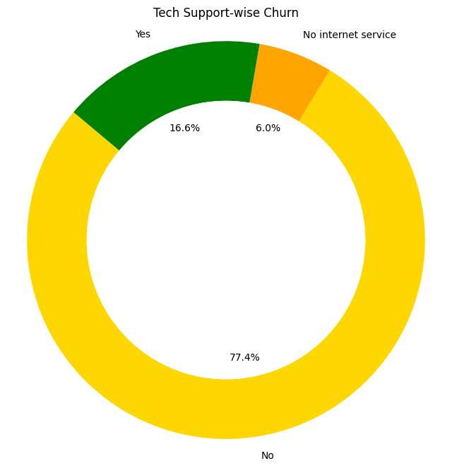

```python
plt.figure(figsize=(8, 8))
wedges, texts, autotexts = plt.pie(techsupport_wise_churn['Churn'], labels=techsupport_wise_churn['TechSupport'], autopct='%1.1f%%', colors=['gold', 'orange', 'green'], startangle=140, wedgeprops=dict(width=0.3))
centre_circle = plt.Circle((0, 0), 0.70, fc='white')
fig = plt.gcf()
fig.gca().add_artist(centre_circle)
plt.title('Tech Support-wise Churn')
plt.axis('equal')
plt.show()
```

The tech support-wise execution of churn provides the finding of maximum churn. In the No-type tech support providing, the maximum churn is found whose percentage is 77.4%.

```python
paymentmethod_wise_churn = data_file[data_file['Churn'] == 1].groupby('PaymentMethod')['Churn'].sum().reset_index()
paymentmethod_wise_churn.head()
```

|  | PaymentMethod | Churn |
| --- | --- | --- |
| 0 | Bank transfer (automatic) | 258 |
| 1 | Credit card (automatic) | 232 |
| 2 | Electronic check | 1071 |
| 3 | Mailed check | 308 |

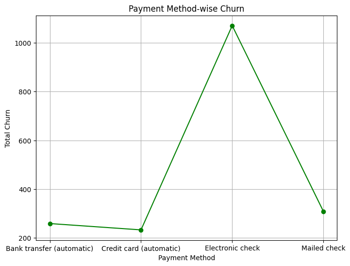

```python
plt.figure(figsize=(8, 6))
plt.plot(paymentmethod_wise_churn['PaymentMethod'], paymentmethod_wise_churn['Churn'], marker='o', linestyle='-', color='g')
plt.xlabel('Payment Method')
plt.ylabel('Total Churn')
plt.title('Payment Method-wise Churn')
plt.grid(True)
plt.show()
```

The payment method-wise executed churn value highlights the maximum churn in the case of an electronic check payment method whose churn value is 1071. The minimum churn is determined in the case of credit cards whose value is 232.

```python
paymentmethod_wise_totalcharges = data_file[data_file['Churn'] == 1].groupby('PaymentMethod')['TotalCharges'].sum().reset_index()
paymentmethod_wise_totalcharges.head()
```

|  | PaymentMethod | TotalCharges |
| --- | --- | --- |
| 0 | Bank transfer (automatic) | 585611.75 |
| 1 | Credit card (automatic) | 545259.80 |
| 2 | Electronic check | 1567576.40 |
| 3 | Mailed check | 164478.95 |

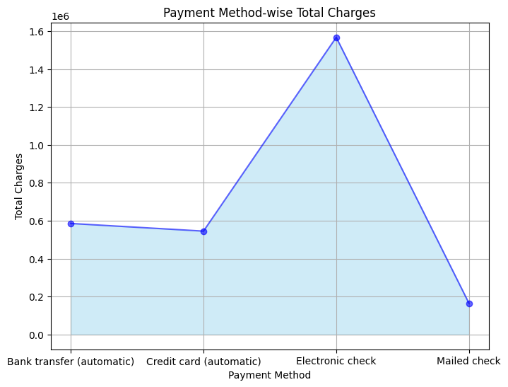

```python
plt.figure(figsize=(8, 6))
plt.fill_between(paymentmethod_wise_totalcharges['PaymentMethod'], paymentmethod_wise_totalcharges['TotalCharges'], color="skyblue", alpha=0.4)
plt.plot(paymentmethod_wise_totalcharges['PaymentMethod'], paymentmethod_wise_totalcharges['TotalCharges'], marker='o', color='blue', alpha=0.6)
plt.xlabel('Payment Method')
plt.ylabel('Total Charges')
plt.title('Payment Method-wise Total Charges')
plt.grid(True)
plt.show()
```

As per the total charge execution, the maximum total charges are executed in the case of the electronic check payment method whose value is 1567576.40.

```python
total_churn_counts = data_file['Churn'].value_counts().reset_index()
total_churn_counts
```

|  | Churn | count |
| --- | --- | --- |
| 0 | 0 | 5174 |
| 1 | 1 | 1869 |

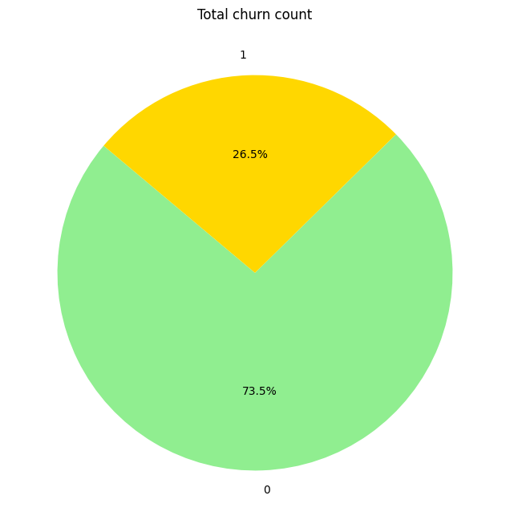

```python
plt.figure(figsize=(8, 8))
plt.pie(total_churn_counts['count'], labels=total_churn_counts['Churn'], autopct='%1.1f%%', colors=['lightgreen', 'gold', 'skyblue'], startangle=140)
plt.title('Total churn count')
plt.show()
```

As per the executable plot, the count of the total number of churn, and non-churn values are highlighted. In this case, 0 is the non-churn part whose percentage is 73.5%, and 1 is the churn part whose percentage is 26.5%.

```python
def final_data_file(data_file):
    if data_file.dtype=='object':
        data_file = LabelEncoder().fit_transform(data_file)
    return data_file
```

```python
data_file = data_file.apply(lambda a: final_data_file(a)).head()
data_file.head()
```

|  | gender | SeniorCitizen | Partner | Dependents | tenure | PhoneService | MultipleLines | InternetService | OnlineSecurity | OnlineBackup | DeviceProtection | TechSupport | StreamingTV | StreamingMovies | Contract | PaperlessBilling | PaymentMethod | MonthlyCharges | TotalCharges | Churn |
| --- | --- | --- | --- | --- | --- | --- | --- | --- | --- | --- | --- | --- | --- | --- | --- | --- | --- | --- | --- | --- |
| 0 | 0 | 0 | 1 | 0 | 1 | 0 | 1 | 0 | 0 | 2 | 0 | 0 | 0 | 0 | 0 | 1 | 2 | 29.85 | 29.85 | 0 |
| 1 | 1 | 0 | 0 | 0 | 34 | 1 | 0 | 0 | 2 | 0 | 2 | 0 | 0 | 0 | 1 | 0 | 3 | 56.95 | 1889.50 | 0 |
| 2 | 1 | 0 | 0 | 0 | 2 | 1 | 0 | 0 | 2 | 2 | 0 | 0 | 0 | 0 | 0 | 1 | 3 | 53.85 | 108.15 | 1 |
| 3 | 1 | 0 | 0 | 0 | 45 | 0 | 1 | 0 | 2 | 0 | 2 | 2 | 0 | 0 | 1 | 0 | 0 | 42.30 | 1840.75 | 0 |
| 4 | 0 | 0 | 0 | 0 | 2 | 1 | 0 | 1 | 0 | 0 | 0 | 0 | 0 | 0 | 0 | 1 | 2 | 70.70 | 151.65 | 1 |

The processing of data provides the approach to the conversion process. This is applicable to configure a function that changes all the object column data into numeric data values.

```python
correlation_df = data_file[['MonthlyCharges', 'tenure', 'TotalCharges', 'Churn']]
```

```python
correlation_matrix_val = correlation_df.corr()
correlation_matrix_val
```

|  | MonthlyCharges | tenure | TotalCharges | Churn |
| --- | --- | --- | --- | --- |
| MonthlyCharges | 1.000000 | -0.109429 | -0.017060 | 0.682338 |
| tenure | -0.109429 | 1.000000 | 0.979043 | -0.640675 |
| TotalCharges | -0.017060 | 0.979043 | 1.000000 | -0.634494 |
| Churn | 0.682338 | -0.640675 | -0.634494 | 1.000000 |

In this case, the target value is set to execute the correlation. This matrix execution supports the best suitable matrix evaluation for this analysis (Punn et al., 2020). The correlation is executed between four data columns such as monthly charges, tenure, total charges, and churn.

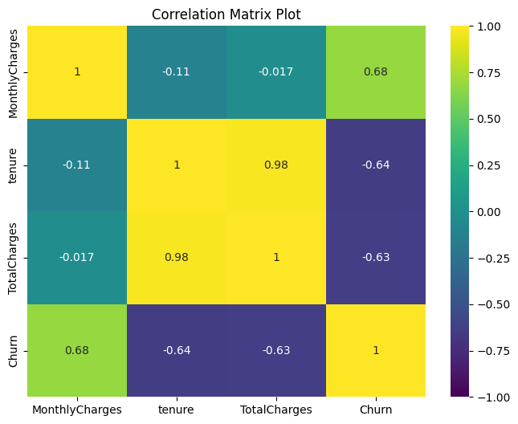

```python
plt.figure(figsize=(8, 6))
sns.heatmap(correlation_matrix_val, annot=True, cmap='viridis', vmin=-1, vmax=1)
plt.title('Correlation Matrix Plot')
plt.show()
```

The correlation plot provides the relational data distribution between four factors such as monthly charges, tenure, total charges, and churn. Each relation has some values, whereas a similar relation has a ‘1’ correlation value.

### Data processing, and Model construction

```python
from sklearn.model_selection import train_test_split
from sklearn.metrics import accuracy_score
from sklearn import metrics
from sklearn.naive_bayes import GaussianNB
from sklearn.neighbors import KNeighborsClassifier
from sklearn.tree import DecisionTreeClassifier
from sklearn.metrics import recall_score, confusion_matrix, precision_score, f1_score, accuracy_score, classification_report
```

```python
x = data_file.drop(columns = ['Churn'])
y = data_file['Churn'].values
```

```python
x_train, x_test, y_train, y_test = train_test_split(x,y,test_size = 0.45, random_state = 40, stratify=y)
```

```python
x_test_val = x_test.to_numpy()
```

The main processing section is the data setting and division portion. In this portion, the categorical column data division, and target column data division. In this portion, the target column is ‘Churn’, whereas the other columns are the categorical column data.

## Model Construction

### Naive Bayes

```python
gb_navv_model = GaussianNB()
gb_navv_model.fit(x_train, y_train)
```

```
GaussianNB()
```

The first model for execution is Naive Bayes which is executed using the x, and y training data.

### KNN

```python
model_KNN = KNeighborsClassifier(n_neighbors=2)
model_KNN.fit(x_train, y_train)
```

```
KNeighborsClassifier(n_neighbors=2)
```

On the other hand, the KNN model is implemented to evaluate the predictive evaluation of the churn of telecom customers.

### Decision Tree

```python
dec_model = DecisionTreeClassifier(criterion='gini', max_depth=None)
dec_model.fit(x_train, y_train)
```

```
DecisionTreeClassifier()
```

Another model for churn prediction is the Decision Tree which is also executed and set using the training data only.

## Model Evaluation

```python
gb_navv_pred = gb_navv_model.predict(x_test)
```

```python
gb_navv_accuracy = accuracy_score(y_test, gb_navv_pred)
print(f"Accuracy Naive Bayes: {gb_navv_accuracy * 100:.2f}%")
```

```
Accuracy Naive Bayes: 33.33%
```

The executed accuracy value for the Naive Bayes model is 33.33%.

```python
gb_navv_report_classification = classification_report(y_test, gb_navv_pred)
print(gb_navv_report_classification)
```

```
              precision    recall  f1-score   support

           0       0.00      0.00      0.00         2
           1       0.33      1.00      0.50         1

    accuracy                           0.33         3
   macro avg       0.17      0.50      0.25         3
weighted avg       0.11      0.33      0.17         3
```

The report of classification defines the f1 and other parameter score values of the model Naive Bayes.

```python
knn_y_pred = model_KNN.predict(x_test_val)
```

```python
knn_accuracy = accuracy_score(y_test, knn_y_pred)
print(f"Accuracy KNN: {knn_accuracy * 100:.2f}%")
```

```
Accuracy KNN: 66.67%
```

The evaluated accuracy value of the model KNN is 66.67%.

```python
knn_report_classification = classification_report(y_test, knn_y_pred)
print(knn_report_classification)
```

```
              precision    recall  f1-score   support

           0       0.67      1.00      0.80         2
           1       0.00      0.00      0.00         1

    accuracy                           0.67         3
   macro avg       0.33      0.50      0.40         3
weighted avg       0.44      0.67      0.53         3
```

The classification details highlight precision and other executable parameter values for KNN.

```python
dec_y_pred = dec_model.predict(x_test)
```

```python
dec_accuracy = accuracy_score(y_test, dec_y_pred)
print(f"Accuracy Decision Tree: {dec_accuracy * 100:.2f}%")
```

```
Accuracy Decision Tree: 33.33%
```

The evaluated accuracy of the predictive determination model Decision tree is 33.33%.

```python
dec_report_classification = classification_report(y_test, dec_y_pred)
print(dec_report_classification)
```

```
              precision    recall  f1-score   support

           0       0.00      0.00      0.00         2
           1       0.33      1.00      0.50         1

    accuracy                           0.33         3
   macro avg       0.17      0.50      0.25         3
weighted avg       0.11      0.33      0.17         3
```

The report defines the recall, and other executable values for 0, and 1 type churn. This predictive determination is executed for the decision tree.

# Discussion

[output not shown]

# Conclusion and Recommendation

It can be concluded that customer turnover is found to be a significant issue in the telecom industry which can impact the company's revenue and the base of customers. Market. With the help of analyzing and predicting the customer joins the telecom companies can better understand the factors which can contribute to the show and take proactive measures for the purpose of retaining the customer. The analysis and the model of machine learning which is outlined can also demonstrate a systematic approach for identifying the address customer with the help of using historical data and the predictive modelling technique.

##### Recommendations

The implementation of predictive analysis can be done for the purpose of continuously in the behavior of customers and crediting the church. It can also be helpful to regularly update models with the new data in order to maintain accuracy and prelims segmentation of the customers (Yadav et al., 2023). This can also be done based upon the question raised which can helpful for the purpose of identifying the retention is strategies as well as providing aggressive retention efforts as well as improvement of service quality.

# References

Bharadiya, J.P., 2023. Machine learning and AI in business intelligence: Trends and opportunities. International Journal of Computer (IJC), 48(1), pp.123-134.

Bharti, R., Khamparia, A., Shabaz, M., Dhiman, G., Pande, S. and Singh, P., 2021. Prediction of heart disease using a combination of machine learning and deep learning. Computational intelligence and neuroscience, 2021(1), p.8387680.

Ghazal, T.M. and Alzoubi, H.M., 2022. Fusion-based supply chain collaboration using machine learning techniques. Intelligent Automation & Soft Computing, 31(3), pp.1671-1687.

Jamil, F., Iqbal, N., Ahmad, S. and Kim, D., 2021. Peer-to-peer energy trading mechanism based on blockchain and machine learning for sustainable electrical power supply in smart grid. Ieee Access, 9, pp.39193-39217.

Mahesh, B., 2020. Machine learning algorithms-a review. International Journal of Science and Research (IJSR).[Internet], 9(1), pp.381-386.

Maulud, D. and Abdulazeez, A.M., 2020. A review on linear regression comprehensive in machine learning. Journal of Applied Science and Technology Trends, 1(2), pp.140-147.

Nabipour, M., Nayyeri, P., Jabani, H., Shahab, S. and Mosavi, A., 2020. Predicting stock market trends using machine learning and deep learning algorithms via continuous and binary data; a comparative analysis. Ieee Access, 8, pp.150199-150212.

Punn, N.S., Sonbhadra, S.K. and Agarwal, S., 2020. COVID-19 epidemic analysis using machine learning and deep learning algorithms. MedRxiv, pp.2020-04.

Ramesh, T.R., Lilhore, U.K., Poongodi, M., Simaiya, S., Kaur, A. and Hamdi, M., 2022. Predictive analysis of heart diseases with machine learning approaches. Malaysian Journal of Computer Science, pp.132-148.

Yadav, A.L., Soni, K. and Khare, S., 2023, July. Heart diseases prediction using machine learning. In 2023 14th International Conference on Computing Communication and Networking Technologies (ICCCNT) (pp. 1-7). IEEE.